# Are you confident in the company, or are you greedy for the price?

## A Time Series Sentiment Analysis project

**Abstract**  
If you don’t know the condition of the market, at least you should know the condition of the company. Under the dynamic market conditions, there are companies that win by brand names and grow persistently over the years despite repressive events such as market calamities, economic downturns, and war. They are known as businesses with durable competitive advantages. An example is Coca-cola, the most popular soft drink company, which recovers its share price from the 1987 crash to exceed its previous peaks within 5 years.There are also companies that only win by prices and often struggle to cope with economic plunges. They are known as price competitive businesses. An example is AT&T, a network service provider, which still hasn’t recovered from an economic recession 10 years ago. Just by watching the news or hearing from friends, you may be holding shares of some persistently-growing companies such e.g. Coca-Cola, but likewise, also holding shares from some of the non-growing companies, e.g. AT&T. Think again why this is. Are you holding the share because it was once sold at a low price? Or are you holding the share because you truly have confidence in the future performance of the company? While a company’s share price is largely constituted by the public’s reaction in news reports, its immunity and resistance towards displeasing economic events are immensely defined by its fundamental health. A company’s fundamental health may be evaluated from the sentiments of it’s quarterly (10-Q) or annual (10-K) reports. In such a sense, company reports may be characterized as its “health records”. Just because a company’s share price is low doesn’t mean there is anything wrong about the company,and vice versa, because the company’s share price is high doesn’t mean it guarantees good performances in the future. With that said, this paper will focus on examining a company’s fundamental health conditions through a case study with Coca-Cola and AT&T’s report sentiments.

**Introduciton**  
Coca-Cola and AT&T are selected as companies to study because they epitomize a fundamentally healthy and a fundamentally weak business, respectively. This allows for an excellent benchmark when used for identifying investment opportunities and making investment decisions. Also, the two companies exist in the market long enough to amount substantial evidence of their fundamental performances. Before examining the fundamental healths of the selected companies, the assumption of the Efficient Market Hypothesis (EMH) should be relaxed because it states that prices reflect all information about the market, as this approach of analyzing the company’s report sentiments lies outside the source of share prices. Exploratory Data Analysis (EDA) is performed to inspect the contribution of each sentiment type towards the companies’ market trend as well as to compare it to the direction of their shares prices albeit making inferences on them. The Susceptible-Infected-Recovered (SIR) Markov Chain model is implemented to monitor the flow of the sentiment types between compartments. Both the local and the global likelihoods of sentiment counts are searched and evaluated using the Iterative Filtering Algorithm (IF2). Also, profile likelihoods for model parameters are estimated to serve the purpose of model predictions in the future. This paper is not aimed to exhaust on high prediction , but rather discuss methods to evaluate the health conditions of public-listed companies.

**Exploratory Data Analysis**  
*Data Collection and Description*  
Full Quarterly Reports (10-Q) dating from March 2001 to September 2019 are collected from the U.S. Securities and Exchange Commission (SEC) for both Coca-Cola and AT&T. The SEC stands out as a reliable source for obtaining corporate information since these information are constructed by corporate experts to best reflect the condition of the companies. Quarterly (10-Q) reports are chosen here to be analyzed because it is available more frequently than the annual (10-K) reports, which allows our models to better capture the changes in the time series of sentiments for each of the companies. Each 10-Q report is parsed to obtain all its embedded words. These words are passed through the SentimentIntensityAnalyzer() function from the “vaderSentiment” package in Python to categorize each word into one of the three sentiment buckets: the positive sentiment buckey, neutral sentiment bucket, and negative sentiment bucket. Note that the “vaderSentiment” package may be biased in attributing likelihoods to word categories because it utilizes a private lexicon to analyze text. In this paper, we set this concern aside. For a company, word count in each sentiment bucket is recorded throughout the 57 quarterly terms, allowing for a total of 57*3=171 sentiment measures. In addition, monthly closing prices for Coca-Cola and AT&T over the past 228 months (19 years) are collected via Yahoo Finance. Yahoo Finance is one of the few platforms that supplies abundant financial data to the public for free.

*Data Pre-processing:*  
To make the sample size more concrete, sentiment measures in quarterly terms are converted to monthly terms through spline interpolation, a polynomial basis technique widely used by economists to estimate gap periods within each time interval. The na_interpolation(option=”spline”) function from the “imputeTS” package in R can achieve this job. After the conversion, the word count for each month simply implies the number of words for a quarterly report if it was reported in that month. Consequently, this provides us with sentiment measures over 228 months, or 228*3=684 data points to work with. These sentiment measures are not standardized since they are expressed in the same units throughout time.

*Preliminary Data Vizualization:*

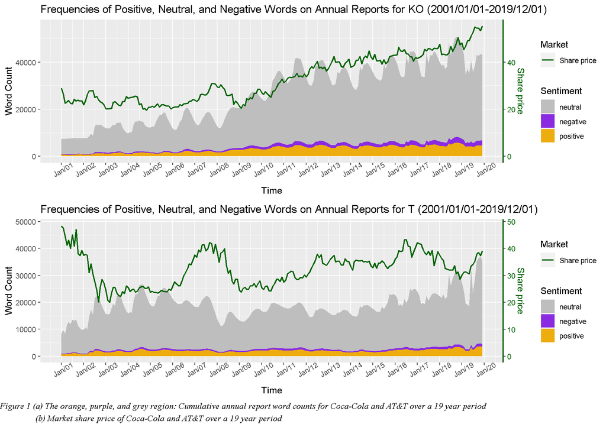

**Dynamic Modeling under the Partially Observed Markov Process (POMP) framework:**  
*Susceptible-Infected-Recovered (SIR) Markov Chain Model:*  
Flow Diagram:  
$S \rightarrow I\rightarrow R$  
In the flow diagram above, each letter represents a compartmental state, for instance, S represents the population susceptible to a disease, I represents the population that is infected by their disease, and R represents the population that is recovering from a disease. We transform the 10-Q report sentiment count data for each company such that they fit into an epidemiological or simply an SIR framework. After this , the sentiment counts and their movements may be represented by the flow chart above. We redefine the compartmental states as follows:  
S: Words that are susceptible to change from one sentiment state to another  
I: Words that that are infected by negative sentiments and are now in the negative sentiment state  
R: Words that recovered from being in the negative sentiment state and is now in the positive sentiment state  
Ordinary Differnetial Equation Interpretation (ODE) of the SIR Model- A discrete-time case:  
$\frac{dN_{SI}}{dt}=\mu_{SI}(t)S(t)$  
$\frac{dN_{IR}}{dt}=\mu_{IR}I(t)$  
Here, $dN_{.}$ denotes the number of population that leaves one compartment and enters into another.  
$\mu_{.}$ denotes the rate that population transit between compartments.  
The Counting Process-counts on words with three states of sentiment:  
$S(t+1)=S(t)-dN_{SI}$  
$I(t+1)=I(t)+dN_{SI}-dN_{IR}$  
$R(t+1)=R(t)+dN_{IR}$  
Euler’s Method- A binomial approximation with exponential transition probabilities: used to solve ODE’s by approximating their respective transition quantities using binomial approximation. For example,  
$dN_{SI}(t)\sim Binomial(S(t),1-exp(-\mu_{SI}(I(t))dt))$

SIR Model Setup:

```
##                se
## -8924.82     0.00
```

A Local Search of the Likelihood Surface:

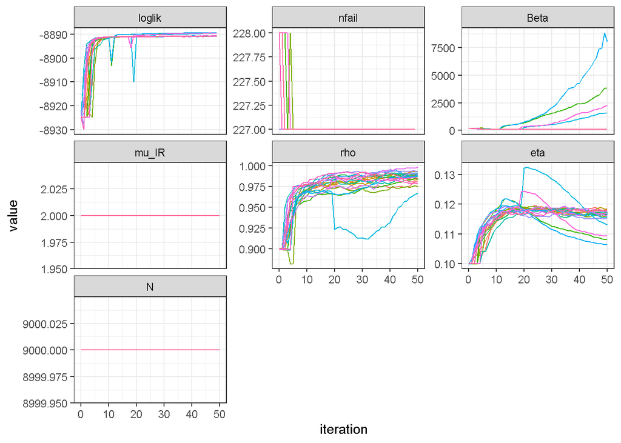

Evaluating the Local Likelihood Search:

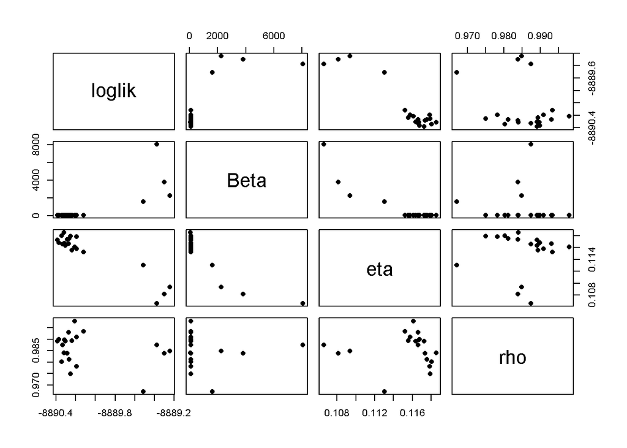

A Global Search of the Likelihood Surface:

A matrix containing self-specified parameter ranges is generated to grant starting values for the global likelihood search . For good parameter estimations, wider ranges of starting values should be specified. As this paper is aimed to introduce simulation methods under the dynamic modeling framework and is not exhaustive in testing for model accuracy, a smaller matrix containing 10 starting values is used. Also, for simplicity, the same number of iterations, replications, and particle filters from the local likelihood searches are used in the global search. Because of the above reasons, it is expected that the predictability of the SIR POMP model is limited. We can see this from the paired plots below.

Evaluating the Global Likelihood Search:

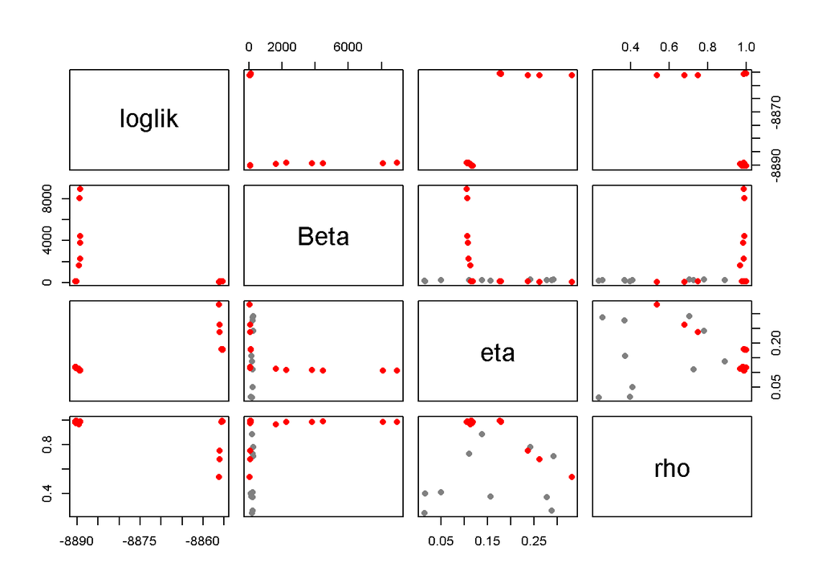

From the paired scatter plots above, grey points representing the parameter starting values and red points indicate the parameter estimates from the IF2 algorithm. This is a relatively small sample range, yet compelling enough to see how the particle filters trace out the estimated likelihoods of each parameter.

Is this likelihood maximization viable?

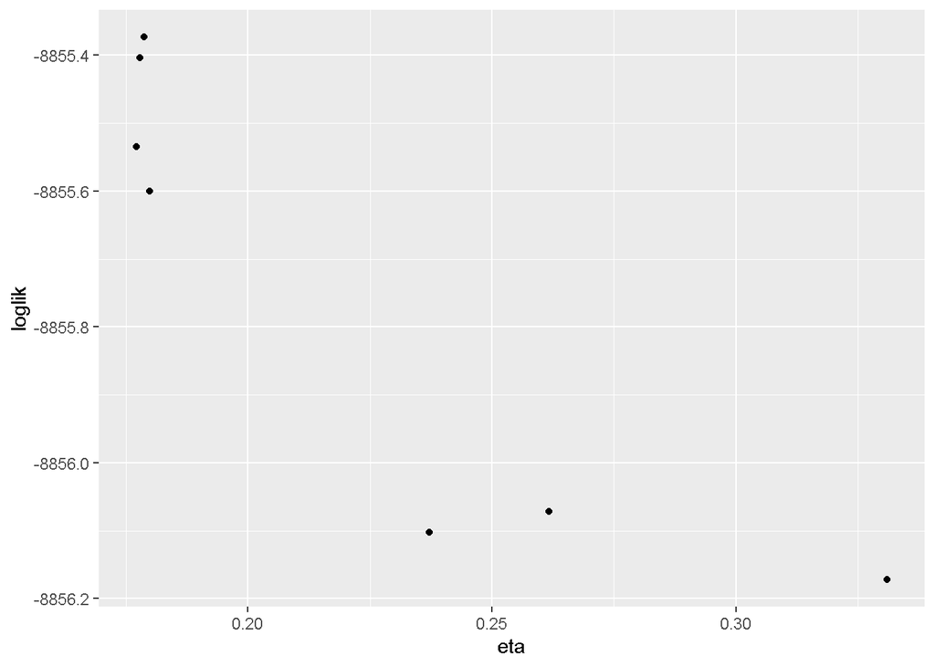

In particular, the paired pot between $\eta$ and its log-likelihoods is displayed to demonstrate the convergence of the parameter estimations. This implication roots from the particles exploring the ranges of parameters and eventually found its way into the high likelihood regions. Therefore, this likelihood maximization seems viable.

Profile Likelihood of $\eta:$

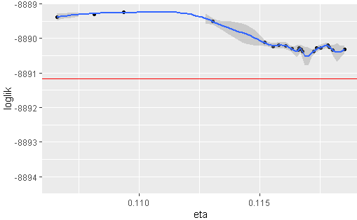

*Ricker Model- Another feasible model for processing sentiemnt counts:*  
$P_{n+1}=rP_{n}exp(-\frac{P_{n}}{k})$  
$Y_{n}\mid P_{n}\sim Negbin(\phi P_{n},\psi)$  
Here,$r$ denotes the intrinsic growth rate of the 10-Q report word count and $k$ denotes the word limit of the report.

Another perspective can be taken to interpret the 10-Q report word counts. Like eoclogical populations, total word counts from one year may be carried over to the next year because the same group of corporate professionals who wrote the report year after year such that its wordings and sentiments may be simliar. The Ricker model is often appropriate in modeling population growth, but in this case, may also be used to model sentiment counts of company reports. Under such framework, no transformation will be needed, thus aiding fewer information loss. However, note that reparameterization may be required so that the scaling of the $P_{n}$ is explicit. Take Coca-Cola for example, we may assume that total word counts for its quarterly reports succeeds those of the previous years. The Ricker model added an exponential growth component to the reports’ total word counts, making it a proper model to fit the growing contents of Coca-Cola’s quarterly report. One may even break down the model by sentiments to scrutinize the sentimental make-up of the report. Or to put this another way, one may dissect a company’s health record and examine its history of transitioning between a “healthy state” (postive sentiment) and an “unhealthy state” (negative sentiment).

*Other Plausible Models:*  
(1) Malthusian Growth Model: (https://en.wikipedia.org/wiki/Malthusian_growth_model)  
(2) Fibonacci Population Growth Model: (https://math.temple.edu/~reich/Fib/fibo.html)  
(3) Verhulst-Pearl (logistic) Model: (https://en.wikipedia.org/wiki/Pierre_Fran%C3%A7ois_Verhulst)

**Conclusion and Thoughts**  
To conclude, dynamic modeling under the POMP framework thorougly moniters the movements of the company’s sentiments. In particular, the SIR model captures an important concern in hte business world: “How good is the company feeling about its performance?”. The IF2 goes beyond answering this question and estimates what the company will feel about their performances in the future. It accomplished this by exploring local regions of the incoming and leaving of word counts that indicates “positive sentiment”, and later explores the global regions of these events. High estimates of words leaving the positive state implies a decline in the health of the company while high estimates of words entering the positive state implies an improvement in health of the company. Only the “health records” of Coca-Cola is studied in this paper. With more time, other veteran companies such as Hersey’s, Moody’s, and Taco Bell, may also be accounted for a more holistic implication. Note that filtering parameters are not changed around too much due to computational limits; more robust estimates may be obtained if particle filters and iterations are set to a higher notch, or if perturbations or cooling factors are changed to yield faster convergence. Coca-Cola is a good starting point, but there are yet many other companies with different sentiemnt properties such that this approach may not stand. The primary takaway is that other than share prices, it is possible to compare companies the dynamic modeling of sentiments from their quarterly (10-Q) or annual (10-K) reports.

**References**  
[1] M.Ebrahimi,A.Yazdavar,A.Sheth, “OntheChallengesofSentimentAnalysisforDynamicEvents”,IEEEIntelligentSystems,2017  
[2] Mehran Azimi and Anup Agrawal,“Is Positive Sentiment in Corporate Annual Reports Informative? Evidence from Deep Learning”,July 2019  
[3] Foteini Kollintza-Kyriakoulia, Manolis Maragoudakis, and Anastasia Krithara,“Measuring the Impact of Financial News and Social Media on Stock Market Modeling Using Time Series Mining Techniques”, 6 November 2018  
[4] EDWARD L. IONIDES, ANINDYA BHADRA, YVES ATCHADÉ, and AARON KING,“ITERATED FILTERING”,The Annals of Statistics 2011, Vol. 39, No. 3, 1776–1802  
[5] https://kingaa.github.io/sbied/mif/mif.html